# Préparation des données

Claude Grasland

2022-10-03

# Préparation des données

```r
library(knitr)
library(dplyr)
library(data.table)
library(readr)
library(sf)
```

```r
library(ggplot2)
```

## Données statistiques sur les logements ordinaires en 2018

Nous partirons des fichiers détail de l’INSEE car, à la différence des tableaux prédéfinis, ils permettent virtuellement toutes les formes de croisement d’indicateurs. Ils sont évidemment beaucoup plus volumineux, mais ce sera justement l’occasion pour les étudiants en data mining d’être confrontés à des problèmes d’optimisation et de big data. On trouve leur description détaillée sur le site de l’INSEE

https://www.insee.fr/fr/statistiques/5542867?sommaire=5395764#consulter

Nous avons opté pour le fichier des individus localisés au canton-ou-ville qui présente une grande polyvalence d’usage puisqu’il permet de reconstituer des tableau agrégés ou l’unité de compte peut-être soit le ménage, soit l’individu selon le critère de pondération adopté.

### Etape 1 : téléchargement des données et stockage temporaire

Nous allons télécharger ici le fichier des données pour la région Ile-de-France au format .csv et l’enregistrer dans un dossier spécial **tmp** qui pourra ulétérieurement être détruit ou déplacé afin de libérer de la place

N.B. Ce programme qui prend quelques minutes sera exécuté une seule fois. On ajoutera ensuite dans l’en-tête du chunk `eval=FALSE` ce qui veut dire que ce bloc de code ne sera plus executé automatiquement lorsqu’on réalise un knit du document Rmd. Il sera néanmoins toujours possible de l’executer manuellement en cliquant sur sa petite flèche verte.

```r
library(curl)
### Téléchargement du fichier INSEE
myurl="https://www.insee.fr/fr/statistiques/fichier/5542867/RP2018_LOGEMTZA_csv.zip"
mydestfile = "tmp/menag2018.zip"
curl_download(url=myurl, destfile=mydestfile)
## Decompression du fichier INSEE
unzip(zipfile = "tmp/menag2018.zip",
      exdir = "tmp")
## Examen du contenu
list.files("tmp")
```

Nous constatons que le document zippé contenait en fait deux fichiers différents

### Etape 2 : Transformation des données au format R

Nous allons pour cela utiliser la fonction `Sys.time()`qui permet de repérer l’heure au début et à la fin d’une action. Les résultats dépendront évidemment de la vitesse de l’ordinateur. Il s’agit ici d’un PC récent de puissance moyenne.

#### Chargement avec la fonction read.csv

- Avec la fonction`read.csv` ui fait partie du **R-base** , le temps de chargement est de 30 secondes. Le tableau résultant est de classe *data.frame* puisque nous avons utilisé une fonction native de R-base

```r
t1<-Sys.time()
tab<-read.csv("tmp/FD_LOGEMTZA_2018.csv", sep = ";", header =T)
t2<-Sys.time()
paste ("chargement effectué en",t2-t1,"secondes")
dim(tab)
class(tab)
```

#### Chargement avec la fonction read_csv2

```r
library(readr)
t1<-Sys.time()
tab<-read_csv2("tmp/FD_LOGEMTZA_2018.csv")
t2<-Sys.time()
paste ("chargement effectué en",t2-t1, "secondes")
dim(tab)
class(tab)
```

#### Chargement avec la fonction fread

- avec la fonction `fread` du package **data.table**, le chargement est effectué en 6 secondes sur le même ordinateur.Le tableau résultant conserve la classe *data.frame* mais possède aussi la classe *data.table* puisque la fonction fread est issue de ce package. Le temps est divisé par cinq comparativement à la fonction de R-base.

```r
library(data.table)
t1<-Sys.time()
tab<-fread("tmp/FD_LOGEMTZA_2018.csv")
t2<-Sys.time()
paste ("chargement effectué en",t2-t1, "secondes")
dim(tab)
class(tab)
```

On voit donc que le temps de chargement peut différer fortement selon le choix des packages. Il en va ensuite de même pour les traitements d’agrégation des données qui seront plus ou moins rapides selon que l’on utilise les fonctions de R-base applicables à un data.frame, celles du package tidyverse applicables à un tibble ou enfin celles du package data.table applicables à un data.table.

### Etape 3 : Sélection des données utiles et sauvegarde au format .Rdata

Nos différentes tableaux peuvent être enregistés au format interne de .R ce qui réduira considérablement leur taille par rapport au fichier texte au format csv qui pèse 522 Mo. Nous allons également limiter la taille du document en ne conservant que les données qui nous intéressent, en l’occurence celles des départements de Paris et Petite Couronne.

Comme ces données bvont nous servir durant tout le projet, elles seront stockées dans le dossier **data** situé à l’intérieur du projet et non pas dans le dossier **tmp** qui sera détruit si l’on n’en a plus besoin pour libérer de la place.

- **N.B. On ramène l’objet à la classe d’objet unique data.frame pour éviter des conflits possibles entre package. On pourra toujours le retransformer ensuite en data.table ou en tibble.**

```r
## Chargement avec fread (+ rapide)
tab<-fread("tmp/FD_LOGEMTZA_2018.csv")

## Suppression de la classe data.table
tab<-as.data.frame(tab)
## Selection des données relatives au Val de Marne
sel<-tab %>% mutate(DEPT=substr(COMMUNE,1,2)) %>% filter(DEPT %in% c("75","92","93","94"))
## Vérification des dimensions du tableau
dim(sel)
## Sauvegarde au format RDS
saveRDS(object = sel,
        file = "data/menag2018.RDS")
```

On peut effectuer de façon facultative une sauvegarde au format .csv ce qui évitera des problème d’ouverture du fichier .Rdata pour les personnes ayant des versions anciennes de R. Mais du coup cela engendrera un fichier très volumineux (200 Mo).

```r
## Sauvegarde au format CSV (facultatif)
write.table(x=sel,
            file = "data/indiv2017.csv",
            sep=";",
            dec = ".",
            fileEncoding = "UTF-8")
```

#### Etape 4 : Chargement et sauvegarde des méta-données

Il ne faut surtout pas oublier le fichier des métadonnées qui va permettre de recoder facilement tous les facteurs et de décoder les chiffres correspondant aux classes. On va donc le transformer au format R puis l’enregistrer également dans le dossier data.

```r
# Lecture du fichier de métadonnées
meta<-fread("tmp/varmod_LOGEMT_2018.csv")
# Enregistrement dans le dossier data
saveRDS(object = meta,
        file = "data/menag2018_meta.RDS")
```

## Données géométriques

Les contours des unités spatiales correspondant aux codes de l’INSEE sont produits par l’IGN et disponibles sur le site géoservice en accès libre :

### Etape 1 : récupération du fonds IRIS au format shapefile

On récupère le fichier des IRIS et on le décompresse :

https://geoservices.ign.fr/ressource/178706

```r
list.files("tmp/iris")
```

```
## [1] "IRIS_GE.CPG" "IRIS_GE.DBF" "IRIS_GE.PRJ" "IRIS_GE.SHP" "IRIS_GE.SHX"
## [6] "LISTE.csv"
```

### Etape 2 : Importation et transformation au format sf

La cartographie et plus généralement les opérations géométriques sur des données spatiales dans R peuvent facilement être effectuées avec le **package sf** (spatial features) qui crée des objets ubniques rassemblant à la fois

- un tableau de données (l’équivalent du fichier .dbf)
- une géométrie (l’équivalent du fichier .shp)
- une projection (l’équivalent du fichier .prj)

Lorsqu’on récupère des fonds de carte au format shapefile (.shp) ou dans d’autres formats standards comme GeoJson, la première tâche consiste donc à les convertir au formt sf afin de pouvoir les utiliser facilement dans R. L’importation se fait à l’aide de l’instruction `st_read` en indiquant juste le nom du fichier .shp à charger. Les autres fichiers (.dbf ou .proj) seront lus également et intégrés dans l’objet qui hérite de la double classe *data.frame* et *sf*

```r
library(sf)
map <- st_read("tmp/iris/IRIS_GE.shp")
dim(map)
```

```
## [1] 48580     7
```

```r
class(map)
```

```
## [1] "sf"         "data.frame"
```

```r
head(map,2)
```

```
## Simple feature collection with 2 features and 6 fields
## Geometry type: MULTIPOLYGON
## Dimension:     XY
## Bounding box:  xmin: 145100.1 ymin: 6787288 xmax: 204824.8 ymax: 6838268
## Projected CRS: RGF93 / Lambert-93
##   INSEE_COM NOM_COM IRIS CODE_IRIS   NOM_IRIS TYP_IRIS
## 1     29019   Brest 0132 290190132 Kerbernier        H
## 2     29274   Scaër 0101 292740101       Nord        H
##                         geometry
## 1 MULTIPOLYGON (((145100.1 68...
## 2 MULTIPOLYGON (((192623.3 67...
```

### Etape 3 : Extraction des IRIS de la zone d’étude

Le fichier comporte près de 50 000 unités spatiales qui correspondent soit à des communes suffisamment grandes pour être découpées en IRIS, soit à des communes non découpées. On reconnaît ces dernières au fait que leur code IRIS se termine par ‘00000’.

```r
map_iris<-map %>% mutate(DEPT = substr(INSEE_COM,1,2)) %>%
             filter(DEPT %in% c("75","92","93","94"))
dim(map_iris)
```

```
## [1] 2752    8
```

```r
class(map_iris)
```

```
## [1] "sf"         "data.frame"
```

```r
head(map_iris,2)
```

```
## Simple feature collection with 2 features and 7 fields
## Geometry type: MULTIPOLYGON
## Dimension:     XY
## Bounding box:  xmin: 648336.6 ymin: 6864611 xmax: 649964.5 ymax: 6867258
## Projected CRS: RGF93 / Lambert-93
##   INSEE_COM                  NOM_COM IRIS CODE_IRIS  NOM_IRIS TYP_IRIS
## 1     75117 Paris 17e Arrondissement 6511 751176511 Ternes 11        H
## 2     92024                   Clichy 0403 920240403     Klock        H
##                         geometry DEPT
## 1 MULTIPOLYGON (((648336.6 68...   75
## 2 MULTIPOLYGON (((649630 6867...   92
```

Le nouveau tableau ne comporte plus que 2752 unités spatiales et 8 colonnes au lieu de 7 puisqu’ l’on a ajouté une colonne DEPT. On peut visualiser le résultat à l’aide de la fonction `geom_sf`du package **ggplot2** :

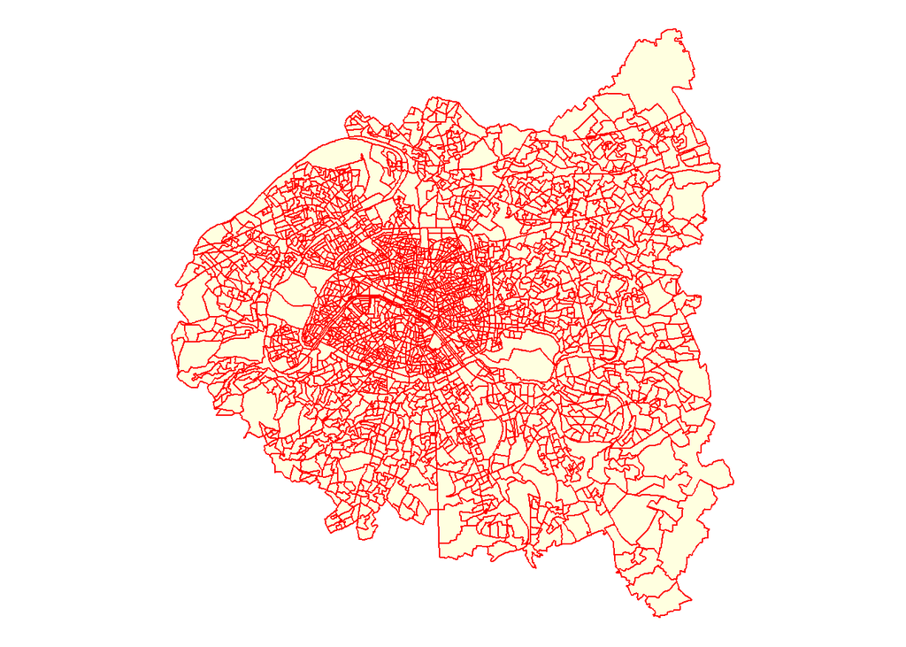

```r
ggplot(map_iris)+geom_sf(fill="lightyellow",col="red") + theme_void()
```

On sauvegarde le résultat dans notre dossier **data** au format interne de R :

```r
saveRDS(object = map_iris,
        file = "data/map_iris.Rdata")
```

### Etape 4 : création d’un fonds de carte des communes

Comme nous serons amenés à travailler à plusieurs échelles, nous produisons tout de suite un fonds de carte des communes en utilisant les fonctions d’agrégation du packages **sf** combinées avec celles de **dplyr**.

```r
map_com <- map_iris  %>% group_by(INSEE_COM) %>%
                        summarise(NOM_COM = min(NOM_COM)) %>%
                        st_as_sf()
```

on vérifie que l’agrégation s’est bien passée :

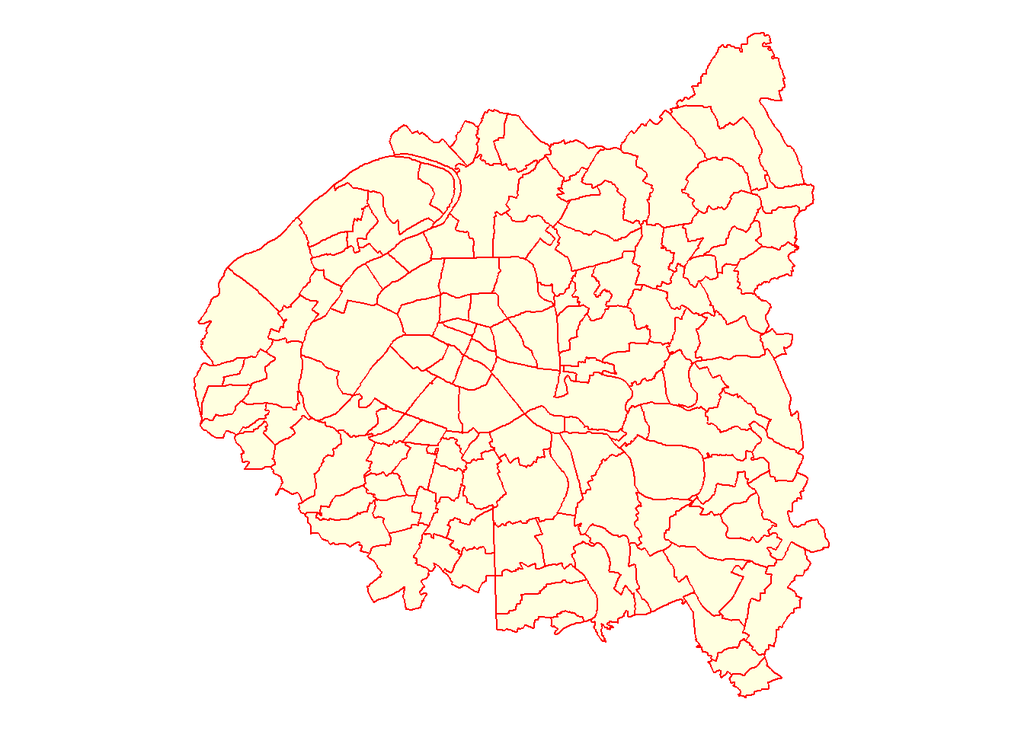

```r
ggplot(map_com)+geom_sf(fill="lightyellow",col="red") + theme_void()
```

Et on sauvegarde le fonds de carte

```r
saveRDS(object = map_com,
        file = "data/map_com.Rdata")
```

### Etape 5 : création d’un fonds de carte par département

Enfin, on construit un fonds de carte des départements selon la même procédure :

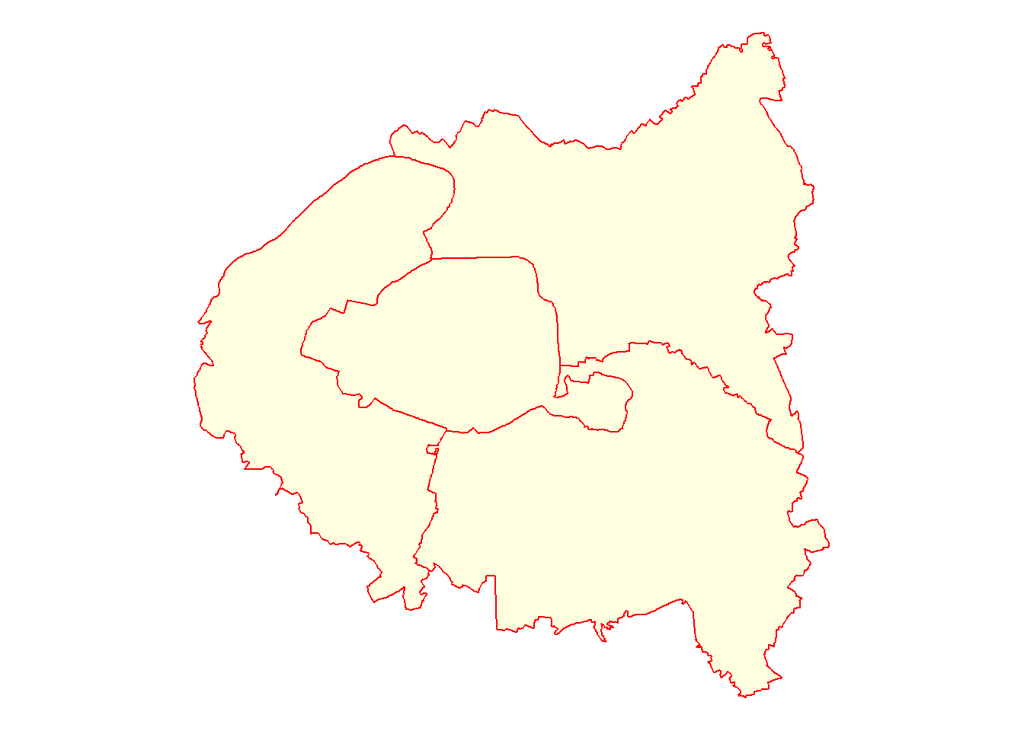

```r
map_dep <- map_iris  %>%     mutate(DEPT = substr(INSEE_COM,1,2))%>%
                        group_by(DEPT) %>%
                        summarise() %>%
                        st_as_sf()
ggplot(map_dep)+geom_sf(fill="lightyellow",col="red") + theme_void()
```

```r
saveRDS(object = map_dep,
        file = "data/map_dep.Rdata")
```

### Etape 6: Superposition des trois fonds de carte

On va utiliser la fonction `plot` du package **sf** qui permet de visualiser la variable *geometry* et facilite les superpositions avec l’instruction `add=TRUE`.

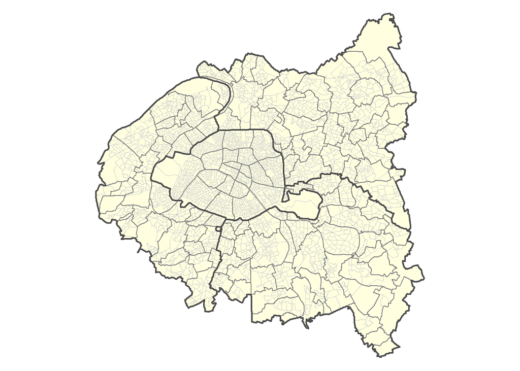

```r
par(mar=c(0,0,0,0))
plot(map_iris$geometry, col= "lightyellow", border = "gray80", lwd=0.5)
plot(map_com$geometry, col= NA, border = "gray50", lwd=1, add=TRUE)
plot(map_dep$geometry, col= NA, border = "gray30", lwd=2, add=TRUE)
```

## Données sur le logement social

Les données sur le logement social sont disponibles sur le site du ministère du développement durable :

https://www.statistiques.developpement-durable.gouv.fr/le-parc-locatif-social-au-1er-janvier-2020-0

### Etape 1 : téléchargement des données géolocalisées

On choisit l’année 2018 pour être le plus en phase possible avec le recensement (même si en pratique celui-ci porte sur 5 ans).

Après téléchargement de l’année 2018, on récupère un dossier zippé avec des données par régions ou par département dans le cas de l’Ile de France.

```r
library(curl)
### Téléchargement du fichier INSEE
myurl="https://www.statistiques.developpement-durable.gouv.fr/sites/default/files/2019-04/rpls-%202018-geolocalise-donnees-detaillees-au-logement_0.zip"
mydestfile = "tmp/rpls2018.zip"
curl_download(url=myurl, destfile=mydestfile)
## Decompression du fichier INSEE
unzip(zipfile = "tmp/rpls2018.zip",
      exdir = "tmp")
## Examen du contenu
list.files("tmp/2018")
```

### Etape 2 : récupértation de Paris + PC

```r
dep75<-fread("tmp/2018/RPLS2018_geoloc_detail_IDF_DEP_75.csv")
dep92<-fread("tmp/2018/RPLS2018_geoloc_detail_IDF_DEP_92.csv")
dep93<-fread("tmp/2018/RPLS2018_geoloc_detail_IDF_DEP_93.csv")
dep94<-fread("tmp/2018/RPLS2018_geoloc_detail_IDF_DEP_94.csv")
tab<-rbind(dep75,dep92,dep93,dep94)
tab<-as.data.table(tab)
saveRDS(tab,"data/RPLS2018.RDS")
```

## Bilan et nettoyage

Nous avons désormais un dossier **data** qui comporte :

1. Le fichier des logements ordinaires en 2018 et ses métadonnées
2. Les fonds de carte par iris, commune et département.
3. Le fichier du RPLS pour l’année 2018

```r
list.files("data")
```

```
## [1] "map_com.Rdata"      "map_dep.Rdata"      "map_iris.Rdata"
## [4] "menag2018.RDS"      "menag2018_meta.RDS" "RPLS2018.RDS"
```

On peut alors décider de détruire le dossier **tmp** qui contient des dossiers très volumineux et pas forcément indispensables.